# QA/QC Check for Pre-FVS data

Eric Lewis-Clark

August 2, 2018

This set of code will preform QA/QC analysis on spreadsheets that are coming from a thirdparty and about to be run in FVS Cloud (or regular FVS)

To start, we will need to load some packages. If you do not have these packages you will need to install them once. To install type: install.packages(“package name”) into the console. Once you have installed all the packages you can run the chunk below.

```r
library(sp)
library(raster)
library(maptools)
library(rgdal)
library(fields)
library(dplyr)
library(odbc)
library(DBI)
library(RSQLite)
```

Now we will set the working directory, bring in files and connect to the database to acccess the TreeInIt and PlotInIt files.

It would be good to have a file setup similar to this: Main Folder (FVS QAQC) within the main folder have 4 folders labeled “code”, “shapefiles”, “databases”, and “results” so everything can run smoothly and you only need to change some names of the input files not pathways

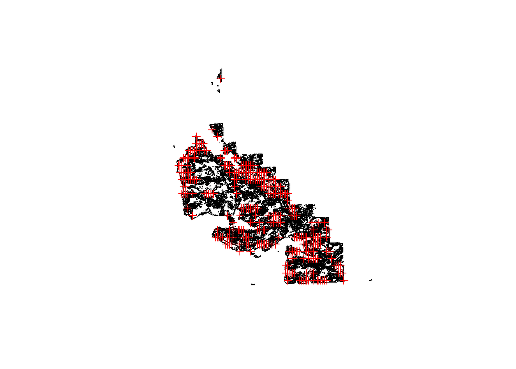

```r
#Set working Directory
setwd("~/FVS QAQC/code")
#Bring the the plot shapefile and the outline shapefile in.
plots<- readOGR("../shapefiles/EBC COMPLETED PLOTS.shp")
outline <- readOGR("../shapefiles/nwk_project_forest_area.shp")
##Plot them to see if this is infact the correct shapefile and plot layout

plot(outline)
plot(plots, add = T, col = "Red")
```

```r
#Connect to the .db database and make sure the files in it are the ones you want to use
con <- dbConnect(RSQLite::SQLite(), "../databases/EBC_FVS_DATA_7_25_18.db")
con
```

```
## <SQLiteConnection>
##   Path: C:\Users\EricLewis-Clark\Documents\FVS QAQC\databases\EBC_FVS_DATA_7_25_18.db
##   Extensions: TRUE
```

```r
alltables = dbListTables(con)
alltables
```

```
## [1] "FVS_GroupAddFilesAndKeywords" "FVS_PlotInit"
## [3] "FVS_StandInit"                "FVS_TreeInIt"
```

```r
#Extract the TreeInIt file and the lost of plot names from the PlotInIt file
##Take a look at them to see if they make sense
Tree <- dbGetQuery(con, 'select * from FVS_TreeInIt')
head(Tree)
```

```
##   Stand_ID StandPlot_ID Plot_ID Tree_ID Tree_Count History Species  DBH DG
## 1       17      NFEBC17      17      70         20       1      98 24.5
## 2       17      NFEBC17      17      71         20       1      98 22.3
## 3       17      NFEBC17      17      72         20       1      98 17.2
## 4       17      NFEBC17      17      73         20       1      98 33.6
## 5       17      NFEBC17      17      74         20       1      98 24.6
## 6       47      NFEBC47      47      75         20       1      98 26.0
##    Ht HTG HtTopK CrRatio Damage1 Severity1 Damage2 Severity2 Damage3
## 1 102          0      50       0         0       0         0
## 2 105          0      50       0         0       0         0
## 3  99          0      40       0         0       0         0
## 4  99          0      45       0         0       0         0
## 5  93          0      50       0         0       0         0
## 6 113          0      65       0         0       0         0
##   Severity3 TreeValue Prescription Age Slope Aspect
## 1
## 2
## 3
## 4
## 5
## 6
```

```r
plotID <- dbGetQuery(con, 'select Plot_ID from FVS_PlotInIt')
head(plotID)
```

```
##   Plot_ID
## 1      17
## 2      47
## 3      48
## 4      75
## 5      77
## 6      78
```

```r
dbDisconnect(con)
```

Now that everything is in we can start running the QA/QC check. First off we will check to make sure that the plot names supplied in the GPS and they plot names in the Database supplied by the contractor are the same

```r
head(plots@data)###Run this code if you are not sure where your plot names are located
```

```
##     ID    UTCDATE              GPSDATUM              MAPDATUM      EPE
## 1 1687 2018-06-24 D_North_American_1983 D_North_American_1983 2.000000
## 2 1718 2018-06-24 D_North_American_1983 D_North_American_1983 2.000000
## 3  173 2018-06-09 D_North_American_1983 D_North_American_1983 2.000000
## 4  142 2018-06-10 D_North_American_1983 D_North_American_1983 2.000000
## 5  297 2018-06-09 D_North_American_1983 D_North_American_1983 2.094950
## 6  204 2018-06-09 D_North_American_1983 D_North_American_1983 3.398350
##   WORSTEPE      HPE WORSTHPE      VPE WORSTVPE   STDDEV     PDOP  MAXPDOP
## 1 2.000000 1.735349 1.888720 4.312400 4.678000 0.271196 2.485000 2.700000
## 2 2.000000 1.051549 1.138044 2.516550 2.583000 0.225803 1.440000 1.500000
## 3 2.000000 1.219529 1.296843 2.760150 2.959000 0.125820 1.605000 1.700000
## 4 2.000000 2.080554 2.081342 5.743350 5.744000 0.591017 3.200000 3.200000
## 5 2.553000 2.089957 4.044247 4.022900 4.764000 0.173076 2.405000 3.300000
## 6 5.036000 2.486776 3.773631 5.358950 8.111000 0.337488 1.850000 2.000000
##       HDOP  MAXHDOP     VDOP  MAXVDOP NUMFIXES NUMSATS MINNUMSATS   PCT_RT
```

[output cut: 34 more lines]

```r
plotshp.df <- data.frame(plots$ID)
head(plotshp.df)
```

```
##   plots.ID
## 1     1687
## 2     1718
## 3      173
## 4      142
## 5      297
## 6      204
```

```r
##Check the length of both sets of Plot IDs. If they are the same we can move on to the next step, to see if they are the same names. If they are not the same length we need to stop and find the discrepencies
length(plotshp.df$plots.ID)
```

```
## [1] 309
```

```r
length(plotID$Plot_ID)
```

```
## [1] 309
```

```r
##Now we can merge and see if they are the same names. If the merge happens with no errors or it returing a NA they have the same names

SameNames <- merge(plotID,plotshp.df, by.x = "Plot_ID", by.y = "plots.ID")
##Check to make sure that you arent getting any error or NAs or 0s by checking the head of the merged file
head(SameNames)
```

```
##   Plot_ID
## 1      17
## 2      47
## 3      48
## 4      75
## 5      77
## 6      78
```

```r
##Check the length again to be sure that the merged file is still the same lenght as the two files going into it
length(SameNames$Plot_ID)
```

```
## [1] 309
```

```r
length(plotshp.df$plots.ID)
```

```
## [1] 309
```

```r
length(plotID$Plot_ID)
```

```
## [1] 309
```

Now we will check for missing data in any of the cloumns.By taking the mean of a dataset we can find out if there are missing values becasue if there are NAs we will get an NA for the mean.

```r
mean(Tree$DBH)
```

```
## [1] 12.243
```

```r
mean(Tree$Ht)
```

```
## [1] 47.97
```

```r
mean(Tree$HtTopK)
```

```
## [1] 1.807857
```

```r
mean(Tree$Stand_ID)
```

```
## [1] 1531.872
```

```r
mean(Tree$Plot_ID)
```

```
## [1] 1531.872
```

```r
mean(Tree$Tree_ID)
```

```
## [1] 52.605
```

```r
mean(Tree$Tree_Count)
```

```
## [1] 25.18571
```

```r
mean(Tree$Species)
```

```
## [1] 100.7304
```

```r
mean(Tree$History)
```

```
## [1] 1.505714
```

```r
mean(Tree$CrRatio)
```

```
## [1] 43.76143
```

```r
mean(Tree$Damage1)
```

```
## [1] 5.485714
```

```r
mean(Tree$Severity1)
```

```
## [1] 0
```

```r
mean(Tree$Damage2)
```

```
## [1] 1.1875
```

```r
mean(Tree$Severity2)
```

```
## [1] 0.1825
```

Now that we know there is no NA in the data lets make sure that all of the fields are the same lenght long

```r
length(na.omit(Tree$DBH))
```

```
## [1] 2800
```

```r
length(na.omit(Tree$Ht))
```

```
## [1] 2800
```

```r
length(na.omit(Tree$HtTopK))
```

```
## [1] 2800
```

```r
length(na.omit(Tree$Stand_ID))
```

```
## [1] 2800
```

```r
length(na.omit(Tree$Plot_ID))
```

```
## [1] 2800
```

```r
length(na.omit(Tree$Tree_ID))
```

```
## [1] 2800
```

```r
length(na.omit(Tree$Tree_Count))
```

```
## [1] 2800
```

```r
length(na.omit(Tree$Species))
```

```
## [1] 2800
```

```r
length(na.omit(Tree$History))
```

```
## [1] 2800
```

```r
length(na.omit(Tree$CrRatio))
```

```
## [1] 2800
```

```r
length(na.omit(Tree$Damage1))
```

```
## [1] 2800
```

```r
length(na.omit(Tree$Severity1))
```

```
## [1] 2800
```

```r
length(na.omit(Tree$Damage2))
```

```
## [1] 2800
```

```r
length(na.omit(Tree$Severity2))
```

```
## [1] 2800
```

Now lets make sure that all the values make sense in terms of an inventory. i.e.the DBH is from 1-100, height is from 5-200…

```r
##Range for DBH should be between 1 and 100

range(Tree$DBH)
```

```
## [1]  1.0 51.2
```

```r
###Range for Heights should be between 5 and 200

range(Tree$Ht)
```

```
## [1]   6 125
```

```r
##Range of canopy cover should be between 0-100
range(Tree$CrRatio)
```

```
## [1]  0 95
```

```r
##Check the arb website for list of acceptable species in the area and make sure that species that are found here are the same as the accepted species

unique(Tree$Species)
```

```
## [1]  98 920 747  42
```

```r
##History should only have 1 (alive) or 9 (dead) trees in it.

unique(Tree$History)
```

```
## [1] 1 9
```

```r
##Tree count should only be 20 (trees DBH >= 5) or 200 (trees DBH < 5)

unique(Tree$Tree_Count)
```

```
## [1]  20   0 200
```

```r
##Make sure that all of the HtTopK are shorter than their corresponding tree

HeightTest <- Tree$Ht - Tree$HtTopK
subset(HeightTest, HeightTest <= 0)
```

```
## integer(0)
```

Now lets make some plots and see if we can se any outlyers in the data. The first group of plots we will make are DBH~Height seperating by species and colored by Crown Cover

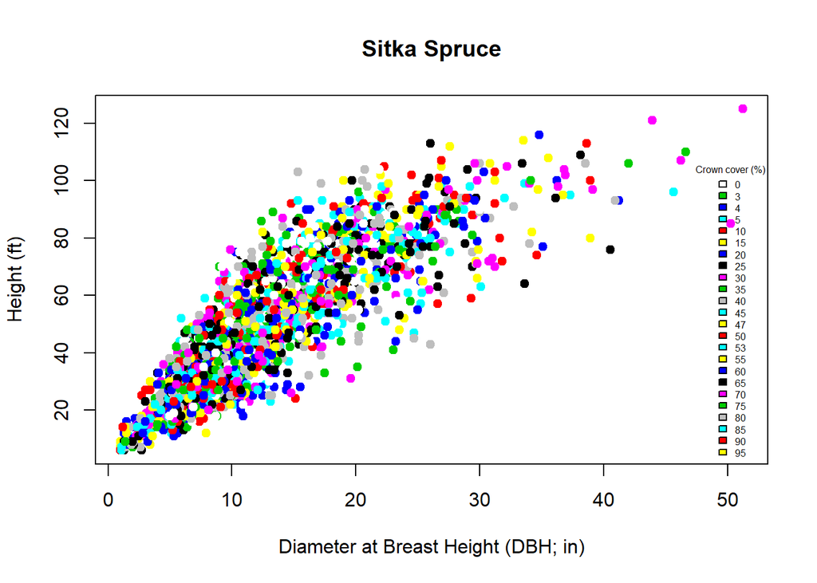

```r
##First lets subset the data into different species
Tree98 <- subset.data.frame(Tree, Tree$Species == 98)
Tree42 <- subset.data.frame(Tree, Tree$Species == 42)
Tree920 <- subset.data.frame(Tree, Tree$Species == 920)
Tree747 <- subset.data.frame(Tree, Tree$Species == 747)

##Now we can make a plot for all the different species
plot(Ht~DBH, data = Tree98, col = CrRatio, pch = 19,
     ylab = "Height (ft)", xlab = "Diameter at Breast Height (DBH; in)",
     main = "Sitka Spruce")
legend("bottomright", legend = sort.int(unique(Tree98$CrRatio)),
       fill = sort.int(unique(Tree98$CrRatio)), bty = "n",
       title = "Crown cover (%)",cex = 0.5)
```

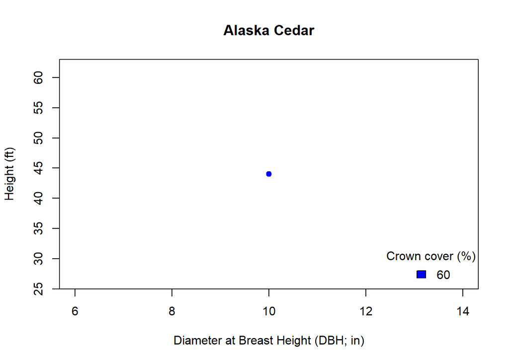

```r
plot(Ht~DBH, data = Tree42, col = CrRatio, pch = 19,
     ylab = "Height (ft)", xlab = "Diameter at Breast Height (DBH; in)",
     main = "Alaska Cedar")
legend("bottomright", legend = sort.int(unique(Tree42$CrRatio)),
       fill = sort.int(unique(Tree42$CrRatio)), bty = "n", title = "Crown cover (%)")
```

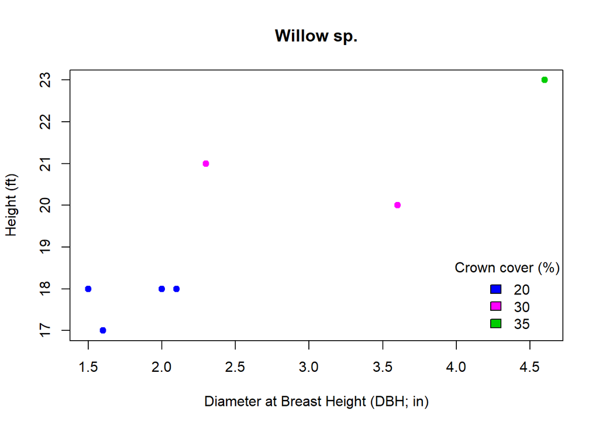

```r
plot(Ht~DBH, data = Tree920, col = CrRatio, pch = 19,
     ylab = "Height (ft)", xlab = "Diameter at Breast Height (DBH; in)",
     main = "Willow sp.")
legend("bottomright", legend = sort.int(unique(Tree920$CrRatio)),
       fill = sort.int(unique(Tree920$CrRatio)), bty = "n", title = "Crown cover (%)")
```

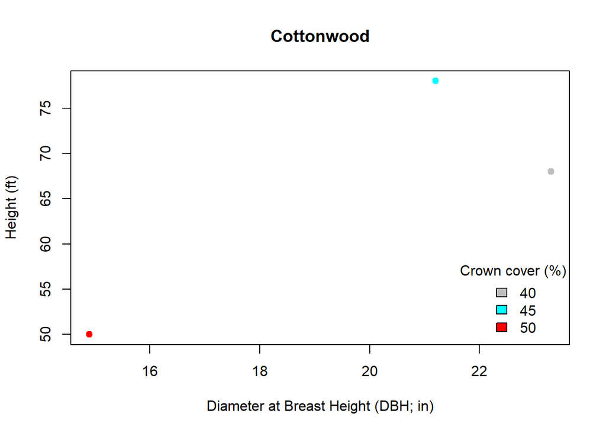

```r
plot(Ht~DBH, data = Tree747, col = CrRatio, pch = 19,
     ylab = "Height (ft)", xlab = "Diameter at Breast Height (DBH; in)",
     main = "Cottonwood")
legend("bottomright", legend = sort.int(unique(Tree747$CrRatio)),
       fill = sort.int(unique(Tree747$CrRatio)), bty = "n",title = "Crown cover (%)")
```

We will also showcase weather the tree had a broken top using the same type of plots

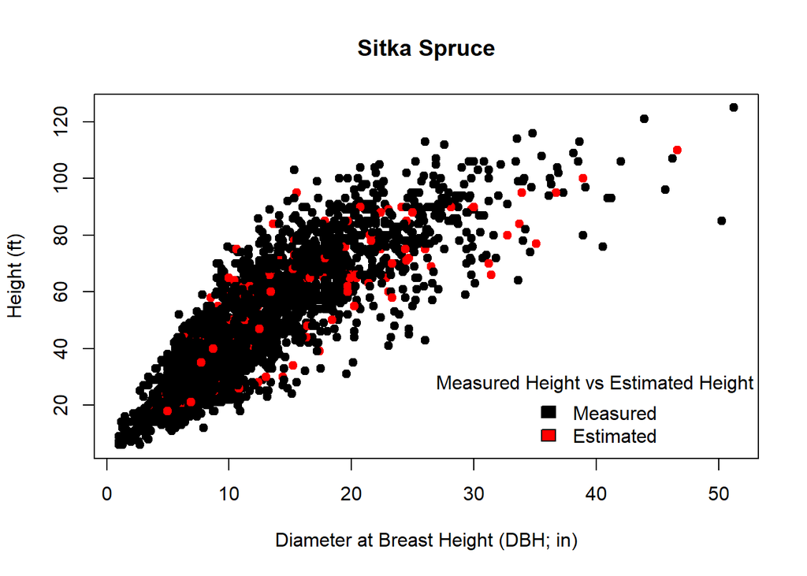

```r
Tree$ME <- Tree$HtTopK

Tree$ME[Tree$ME >0] <- 2
Tree$ME[Tree$ME == 0] <- 1

Tree98 <- subset.data.frame(Tree, Tree$Species == 98)
Tree42 <- subset.data.frame(Tree, Tree$Species == 42)
Tree920 <- subset.data.frame(Tree, Tree$Species == 920)
Tree747 <- subset.data.frame(Tree, Tree$Species == 747)

plot(Ht~DBH, data = Tree98, col = ME, pch = 19,
     ylab = "Height (ft)", xlab = "Diameter at Breast Height (DBH; in)",
     main = "Sitka Spruce")
legend("bottomright", legend = c("Measured", "Estimated"),
       fill =c(1,2), bty = "n", title = "Measured Height vs Estimated Height")
```

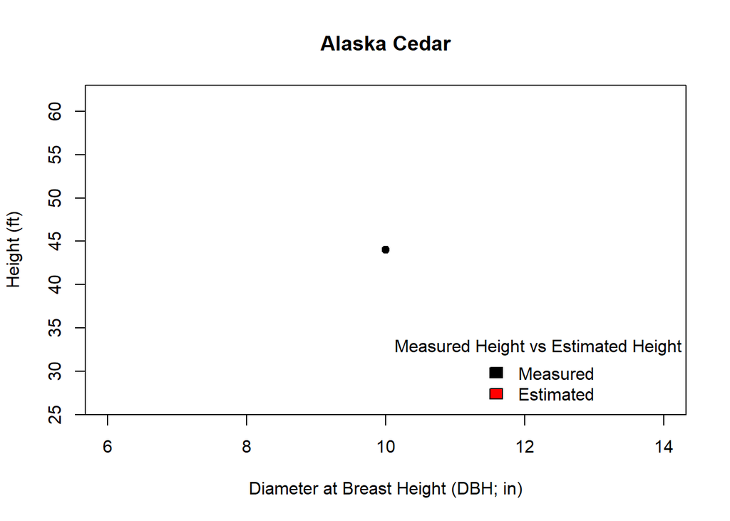

```r
plot(Ht~DBH, data = Tree42, col = ME, pch = 19,
     ylab = "Height (ft)", xlab = "Diameter at Breast Height (DBH; in)",
     main = "Alaska Cedar")
legend("bottomright", legend = c("Measured", "Estimated"),
       fill =c(1,2), bty = "n",title = "Measured Height vs Estimated Height")
```

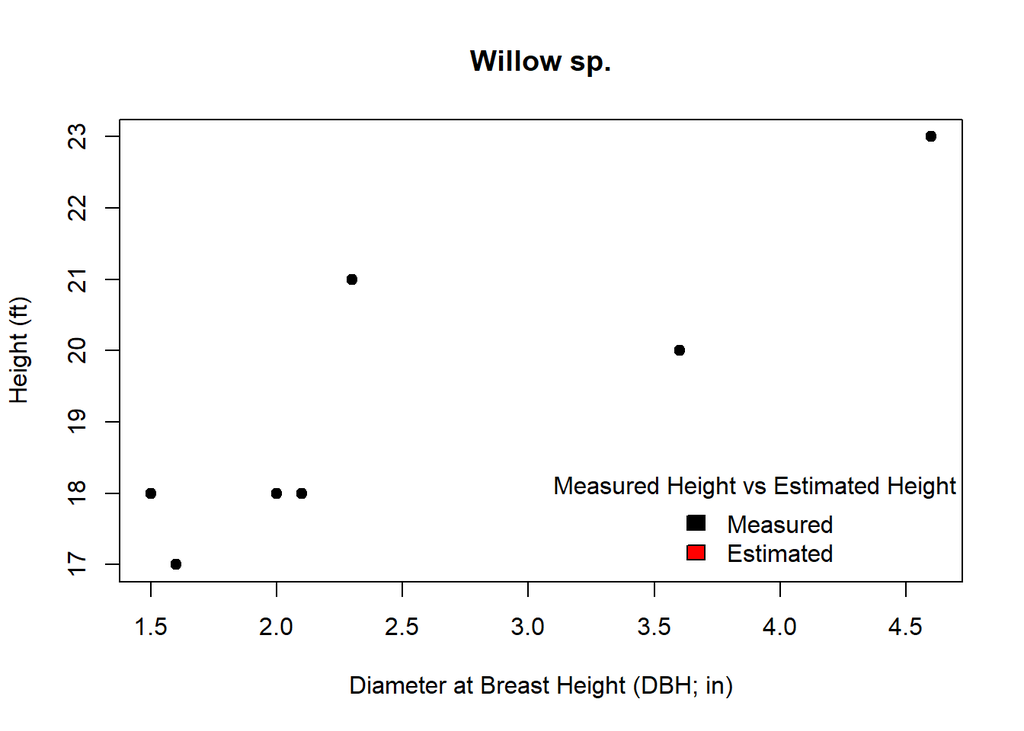

```r
plot(Ht~DBH, data = Tree920, col =ME, pch = 19,
     ylab = "Height (ft)", xlab = "Diameter at Breast Height (DBH; in)",
     main = "Willow sp.")
legend("bottomright", legend = c("Measured", "Estimated"),
       fill =c(1,2), bty = "n", title = "Measured Height vs Estimated Height")
```

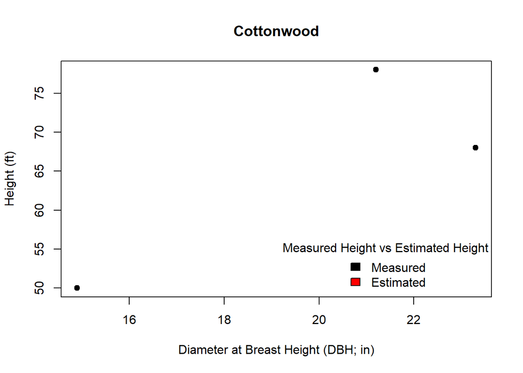

```r
plot(Ht~DBH, data = Tree747, col = ME, pch = 19,
     ylab = "Height (ft)", xlab = "Diameter at Breast Height (DBH; in)",
     main = "Cottonwood")
legend("bottomright", legend = c("Measured", "Estimated"),
       fill =c(1,2), bty = "n",title = "Measured Height vs Estimated Height")
```

Lets check to see if there are any “problem” plots. i.e. plots that only have dead trees, plots that have only tally trees and plots that have no trees

```r
#First we will look to see if there are any plots with only tally trees in them
plotmaxDBH <- aggregate(Tree, list(plot = Tree$Plot_ID), max)
summary(plotmaxDBH$DBH)
```

```
##    Min. 1st Qu.  Median    Mean 3rd Qu.    Max.
##    5.00   16.85   23.10   22.97   28.10   51.20
```

```r
smallmax <- subset.data.frame(plotmaxDBH, plotmaxDBH$DBH < 5)
smallmax$Plot_ID
```

```
## integer(0)
```

```r
## Next we will determine if there are any plots with only dead trees in them.
Tree$dead <- Tree$History
Tree$dead[Tree$History == 9] <- 0

Dead_Plot <- aggregate(dead ~ Plot_ID, data = Tree, sum)
subset(Dead_Plot, Dead_Plot$dead == 0)
```

```
## [1] Plot_ID dead
## <0 rows> (or 0-length row.names)
```

```r
##Finally lets see if there are any differences in our plots from PlotInIt and TreesInIt

c(setdiff(unique(Tree$Plot_ID), plotID$Plot_ID), setdiff(plotID$Plot_ID, unique(Tree$Plot_ID)))
```

```
##  [1]  168  571  751  782  874 1403 1658 1687 1955 2582
```

```r
##These are the missing plots
```